# integracionMC

## Introducción

**Resumen:**

En este capítulo introducimos diferentes algoritmos de Monte Carlo para estimación de integrales. Veremos los algoritmos de aceptación / rechazo y los algoritmos basados en medias. Analizaremos el error en la estimación a través de la varianza del estimador y se presentarán diferentes técnicas para reducir la varianza del estimador.

**Conclusiones**

- Todos los algoritmos de integración de Monte Carlo realizarán una estimación puntual de la integral utilizando muestras de tamaño $n$, $n \rightarrow \infty$.
- El error cometido en la estimación es proporcional a la varianza del estimador.
- El error decrece con el tamaño de la muestra. Para los algoritmos de Monte Carlo este se comporta como $O \left( \frac{1}{ \sqrt{n}} \right)$ independientemente de la dimensión $d$ del problema. En los algoritmos de integración numérica el error depende de la dimensión $d$ del problema. Por ejemplo en los algoritmos de integración que utilizan la regla trapezoidal $O( N^{-2/d})$.
- Se presentan diferentes técnicas para reducir la varianza del estimador. La mas relevante es el muestreo por importancia (IS). En IS se selecciona la muestra de forma que esta sea mayoritaria en aquellos lugares con una mayor contribución a la integral.
- El muestreo por importancia permite hacer estimaciones del valor esperado de una transformación de una v.a $X$ utilizando una muestra de otra distribución.

**Requisitos:**

- Para entender esta lectura es necesario conocer y comprender los conceptos de variable aleatoria, p.d.f, c.d.f y teorema central del límite vistos en el Tema 1.
- *Muy importante*: No confundir la varianza del estimador $\left( \frac{\sigma^2}{\sqrt{n} } \right)$, la varianza de la variable aleatoria que se emplea en el estimador ($\sigma^2)$ y la varianza de la muestra $(s^2)$.

## Algoritmo aceptación / rechazo:

Supongamos que $g(x)$ es una función no-negativa de la que se desa hallar su área $A_D \equiv I = \int_{a}^{b} g(x) \, dx$ . Definnamos la región rectangular que la encierra $ R \doteq [a, b] \, \mathsf{x} \, [0, d] $ donde $d$ es mayor o igual al valor máximo de la función $g(x)$ en el intervalo $(a,b)$, $d \geq \max_ { x \in (a,b)} g(x) $. El área del rectángulo es $A_R = (b-a) \ d$

**Algoritmo**

El siguiente algoritmo produce una estimación $\widehat{A}_D$ del área buscada $A_D$ utilizando el método de aceptación y rechazo:

*Descripción:*

- Generar una muestra de tamaño $n$ perteneciente a una distribución uniforme $ U \sim \mathcal{U}(a,\, b)$
- Generar una segunda muestra de tamaño $n$ extraída de una distribución uniforme $ V \sim \mathcal{U}(0,\, d)$
- Con ambas muestras obtener un conjunto de $n$ puntos aleatorios en la región rectangular $R$: $$ ((U_i, V_i) \rightarrow (x_i, y_i) )_{i=0...n} $$
- Para cada uno de los puntos anteriores evaluar si pertenece a la región $D$: si pertenece a dicha región se acepta y sino se rechaza. Sea $S_n$ el ratio del total de puntos aceptados y el total de puntos generados.
- La magnitud $\widehat{A}_D = S_n d \, (b-a) $ es una estimación del área $A_D$ y por tanto de la integral $I$.
- La Varianza $\text{Var} \left[S_n \right] $ es una medida del eroor del estimador

*Pseudicódigo:*

1. **sample:** $u_1, u_2, \cdots , u_n \sim \mathcal{U}(a,b)$ **and** $v_1, v_2, \cdots , v_n \sim \mathcal{U}(0,d)$
2. **for** $i$ **in** $[1, 2, \cdots ,n]$ :
   - **if** $f(u_i) \geq v_i$ :
     - $X_i = 1$
   - **else** :
     - $X_i = 0$
3. **return** ${S_n} = \frac{1}{n}\sum_{i=1}^{i=n} X_{i}$

Por tanto la estimación del área será: $$ \widehat{I} = S_{n} A_R = S_{n} \ d \ (b-a) $$

*Discusión:*

- $X$ en una variable aleatoria que se distribuye según una distribución de Bernoulli (éxito / fallo) $X \sim Bern(p)$, donde la probabilidad de éxito $p$ es, en esta caso, la *probabilidad de aceptar el punto* $p=\frac{A_D}{A_R}$.
- En una distribción de Bernuolli el valor esperado $\mu = E[X] = p$ y la varianza $\sigma^2 = p \ (1-p)$.
- La media muestral $ S_n$ es un estimador puntual del valor esperado de $X$.
- La varianza de la media muestral $\text{Var}\left[ S_n \right] $ es una medida del error cometido en la estimación. Por el Teorema central del límite sabemos que $\text{Var}\left[ S_n \right] = \frac{\sigma^2}{n}$.
- El intervalo de confianza al estimar $\mu$ por medio de $S_n$ con una confianza de $1-\alpha$, (siendo por ejemplo $\alpha=0.05$) es $$ \text{Error} \, = 2 \, z_{\alpha / 2} \frac{\sigma}{\sqrt{n}} $$ donde $\sigma²$ es la varianza de $X\sim Bern(p)$ y $z_{\alpha / 2}$ el precentil correspondiente al valor de $\alpha$ elegido. Para poder evaluar el error de $ S_n$ necesitamos conocer el valor de $\sigma^2$. Al ser $X$ una distribución de Bernuolli $\sigma^2 = p \ (1-p)$ y su varianza será $\sigma^2 = \frac{A_D}{A_R} \left( 1 - \frac{A_D^2}{A_R^2} \right)$

> **Ejemplo I**

> Supongamos la función: $$ f(x) = \sin( 2\pi x)^5 - 2 \cos \left( 3 \cos \left( \frac{x}{\pi} \right)^2 \right)^3 $$ y el intervalo $(a,b) = (0, 10)$. Estimar el área delimitada por la función $f(x)$ en el intervalo $(a,b)$. Evaluar (gráficamente) la precisión (incertidumbre) de la estimación.

```
Integracion: 12.255 Estimación: 12.226
```

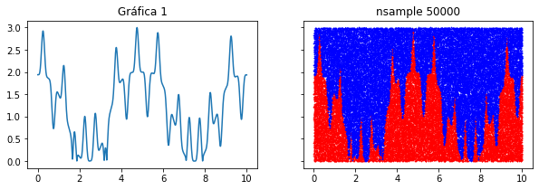

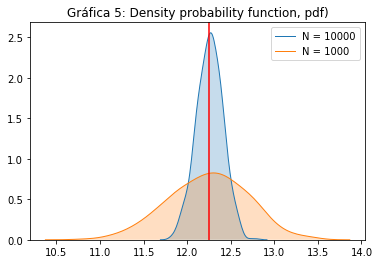

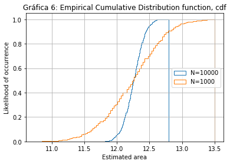

## Algoritmo basado en medias

### Introducción

En el capítulo anterior vimos que dada una variable aleatoria $X$ con p.d.f conocida $f(x)$, el valor esperado de la v.a Y=$h(X)$ para una transformación continua $h(x)$ se define como \begin{equation} \mu = E\left[ Y \right] = E \left[ h(x) \right] = \int_{\Omega} h(x) \, f(x) \, dx \label{y} \end{equation} donde $\Omega$ es el dominio de $f(x)$.

Además sabemos por el teorema de los grandes números que el valor esperado de una v.a $X$ se puede estimar con una muestra $\{ X_1, X_1, \cdots , X_n \}$ utilizando como estimador puntual la media muestral $S_n = \frac{1}{n} \sum_{i=1}^n X_i$.

Para estimar el valor esperado (\ref{y}) emplearemos la misma estrategia: extraemos una muestra de la distribución de $X$ y construímos el estimador evaluando $h(X)$ para cada uno de los valores de la muestra, $$ \widehat{\mu} = \frac{1}{n} \sum_{i=1}^{n} h \left( X_i \right) \label{eq:estimador} $$

Por el Teorema central del límite, el intervalo de confianza del estimador (\ref{eq:estimador}) es

$$ \text{Error} \, = \, z_{\alpha / 2} \frac{\sigma}{\sqrt{n}} $$

donde $\sigma^2$ representa la varianza de la v.a $Y=h(X)$. Como estimación de $\sigma²$ podemos utilizar la varianza muestral $s²$ que en este caso será $$ s^2(n) = \frac{1}{n-1} \sum_{i=1}^n \left( h(X_i) - \widehat{\mu} \right)^2 $$

**Ejercicio II** >

> Calcular la integral $\int_0^1 \left(1 - X^2 \right)^{1/2} dx = \frac{\pi}{4}$.

> Este problema es equivalente a calcular el valor esperado de la transformación $Y=h(X)$ para $h(X) = \left(1 - X^2 \right)^{1/2}$ con $X\sim U(0,1)$

> $$ f(x)=\begin{cases} 1 & 0 \leqslant x \leqslant 1 \\ 0 &\text{otherwise}\end{cases}. $$

> Compare los resultados con los proporcionados con el algoritmo de aceptacion / rechazo analizando los histogramas de las simulaciones.

> *Algoritmo:*

> **sample:** $u_1, u_2, \cdots , u_n \sim \mathcal{U}(0,1)$

> **return** $S_n = \frac{1}{n}\sum_{i=1}^{n} h(u_{i})$

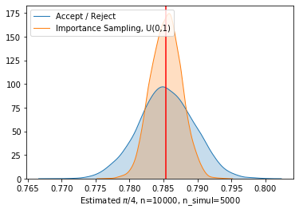

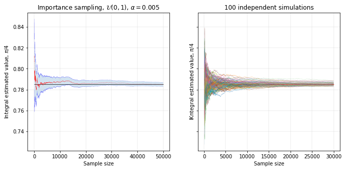

**Ejercicio III** >

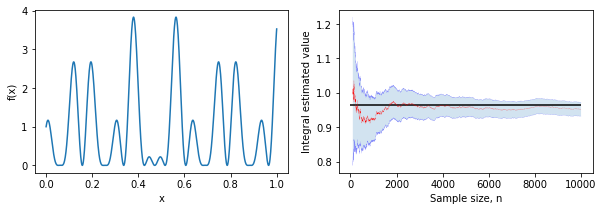

Suponed que queremos evaluar la integral en un intervalo $[a, b]$ cualquiera, $ I = \int_a^b g(x) \, dx. $ Podemos estimar $I$ utilizando una variable aleatoria uniforme $X \sim \mathcal{U}(a,b)$ $$ I = \int_a^b (b-a) \ g(x) \frac{1}{(b-a)} dx = \int_a^b h(x) f(x) \, dx $$ donde $h(x) = (b-a) g(x)$ y se ha tenido en cuenta que la p.d.f de $X \sim \mathcal{U}(a,b)$ $$ f(x)=\begin{cases}\frac{1}{b-a} & a \leqslant x \leqslant b\\ 0 &\text{otherwise}\end{cases}.$$

Para ello utilizaremos el siguiente algoritmo:

**sample:** $u_1, u_2, \cdots , u_n \sim \mathcal{U}(a,b)$

**return** $S_n = \frac{1}{n}\sum_{i=1}^{n} (b-a) \ g(u_{i})$

### Muestreo por importancia

La idea anterior podemos extenderla para el cálculo de cualquier función continua. Supongamos que queremos calcular la integral $ I = \int_{\Omega} g(x) dx. $ en una región $\Omega$. Podríamos estimarla utilizando una variable aleatoria $X$ con p.d.f $f(x)$ siempre que esta tuviese el mismo dominio que la integral, $$ I = \int_{\Omega} \frac{g(x)}{f(x)} f(x) \, dx = \int_{\Omega} h(x) f(x) \, dx $$ siendo $h(x) = \frac{g(x)}{f(x)}$

A la distribución $f(x)$ se le denomina *función de importancia*.

1. **sample:** $X_1, X_2, \cdots , X_n \sim \mathcal{F}$
2. **for** $i$ **in** $[1, 2, \cdots ,n]$ :
   - $ Y_i = h(X_i) = \frac{g \left( X_i \right)}{f \left( X_i \right)}$
3. **return** ${S_n} = \frac{1}{n}\sum_{i=1}^{i=n} Y_{i}$

**Ejercicio IV:**

> Estimar el valor de la integral $$ I = \int_0^{10} e^{-2 \left| x - 5 \right|} \, dx $$

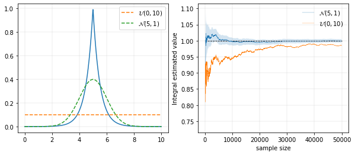

**Ejercicio V:** >

> Suponed que desconocemos la c.d.f. de una v.a $\mathcal{N}(0, 1)$. Aproximar por Monte Carlo el área bajo la p.d.f en el intervalo $[-50, 50]$. Esta cantidad será extremadamente cercana a 1, "de hecho" es 1. Este ejercicio es muy ilustrativo aunque su interés sea puramente académico.

> Utilizaremos una serie de funciones de muestreo de importancia para ilustrar el método:
> - una densidad uniforme $\mathcal{U}(-50, 50)$,
> - una densidad Cauchy truncada en el intervalo $[-50, 50]$
> - una distribución $t$ de 30 grados de libertad truncada en el mismo intervalo.

> La figura muestra las tres funciones de muestreo como una curva punteada junto a la curva normal. Debajo de cada uno de estas se representa el histograma realizado con 5.000 estimaciones de Monte Carlo (utilizando un tamaño de muestra n = 1000) del área bajo la curva normal. Como se observa de la progresión de (a) a (c), *la estimación de la integral tiene una menor varianza cuando la función utilizada en el muestreo de importancia sa haya más próxima a la forma de la densidad normal* (Nota: la característica importante es que la *forma* de la curva sea similar. Obviamente $g(x)$ y $f(x)$, en general, no tendrán la misma altura).

> **¿Por que?** Fijate en la estimación realizada utilizando la distribución uniforme. Los *puntos* $X_i$ que forman la muestra se distribuyen uniformemente en el intervalo [-50, 50]. Esto implica que la mayoría de ellos no contribuirán al valor de la integral: la distribución normal *cae* muy rápido según nos alejamos de su valor medio. Tan solo unos cuantos puntos de la muestra, aquellos que estén en el entorno de 0, contribuirán significativamente al valor de la integral. Sin embargo en estas condiciones la varianza será muy grande. ¿Qué intentamos con el **muestreo con importancia**? Reducir el número de puntos de la muestra que no contribuyan a la integral *eligiendo una muestra **importante** en el sentido que la mayoría de sus puntos se localicen en el entorno del pico*.

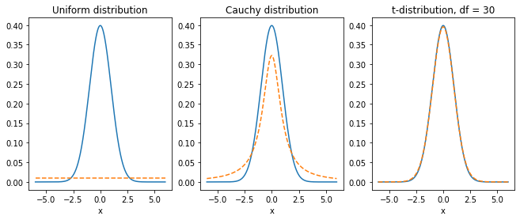

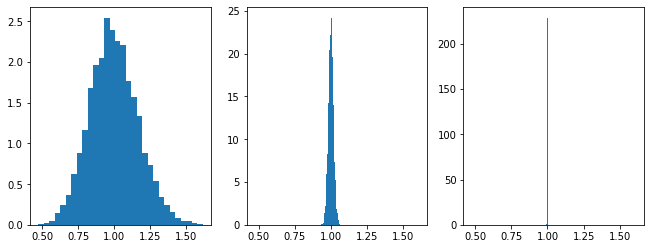

```
numero de simulaciones cuyo estimador excede 1.5: 43
[ 2.306  2.465  1.686  1.638  2.269  1.784  1.561  3.783  1.891  2.623
  5.354  2.761  2.385  2.083  4.719  7.287  1.707  1.553  1.559 53.132
  3.481  2.113  1.726 29.119  2.241  1.504  1.9    1.66   2.687  2.276
  1.658  6.449 17.664  1.986  1.875  3.517  1.518  1.873  3.589  1.566
  2.013  1.613  1.539]
```

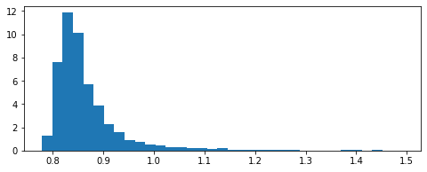

**Ejercicio VI:** >

> Un error común del muestreo por importancia consiste en despreciar la contribución de las colas de las distribuciones. Aunque la función de importancia $f(x)$ pueda tener aproximadamente la misma forma que $g(x)$, surgirán dificultades serias si $f(x)$ disminuye más rápidamente que $g(x)$ en las colas. En tal caso, aunque es improbable que aparezca un valor $X_i$ perteneciente a la cola lejana de $f(x)$, $X_i$ es un evento raro, si lo hace, entonces el estimador de Monte Carlo se verá seriamente afectado por el valor de $g(x)/f(x)$ correspondiente a $X_i$.  
> En estas circunstancias el ratio $\frac{g(X_i)}{f(X_i)}$ puede ser varios órdenes de magnitud mayor que los valores típicos de $\frac{g(X)}{f(X)}$.

> La siguiente figura muestra el histograma de 5000 estimaciones de Monte Carlo del área entre -50 y 50 de densidad de una distribución de Cauchy (truncada en -50 y 50 y renormalizada de modo que el área exacta sea 1) cuando se utiliza como función de importancia la densidad normal estándar (que, obviamente, decrece en las colas mucho más rápidamente que la distribución de Cauchy). Nótese en particular que alrededor de 43 de las 5,000 estimaciones de Monte Carlo para el área de la función de Cauchy truncada fueron mayores que 1.5, en este ejemplo algunas incluso fue superior a 53!!.

**Ejercicio VII:**

> Suponga la v.a $X \sim \mathcal{N}(0,1)$ Estime mediente métodos de Monte Carlo la $P(X>4.5)$ suponiendo que desconocemos su c.d.f. $$ I = \frac{1}{2\sqrt{\pi}} \, \int_{4.5}^{\infty} e^{-\sigma^2 / 2} \,dx $$

> *Solución 1:*

> Podríamos definir la función $f(x)$ con el dominio $[\infty, \infty]$ $$ f(x) = \begin{cases} \frac{1}{2\sqrt{\pi}} e^{-\sigma^2 / 2} & 4.5 \leqslant x \\ 0 &\text{otherwise} \end{cases} $$ y estimar la integral $I = \int_{-\infty}^{\infty} g(x) \, dx$ utilizando como función de importancia la distribución normal $\mathcal{N}(0,1)$

> El problema con esta estrategia es que dado que la $P(X>4.5)$ es $\sim 10^{-6}$, estamos interesados en eventos muy raros, la probabilidad de obtener una muestra mayor de 4.5 (esto es la probabilidad de $g(X) \neq$ 0) requeriría una gran cantidad de iteraciones para obtener una respuesta estable.

> *Solución 2*:

> Si utilizamos otra *función de importancia importancia*, podemos mejorar nuestra precisión y reducir el número de iteraciones en varios órdenes de magnitud. Por ejemplo, si consideramos una distribución con soporte restringido al intervalo $[4.5, \infty]$, la variación adicional e innecesaria del estimador de Monte Carlo debido a la presencia de ceros cuando $x <4.5$ desaparece.

> Una elección natural es elegir como función $f(x)$ la distribución exponencial $\mathcal{Exp}(1)$ truncada en el intervalo $[4.5, \infty]$ $$ f(x) = \frac{e^{-x}}{\int_{4.5}^{\infty} e^{-x} \, dx} = e^{x-4.5} $$

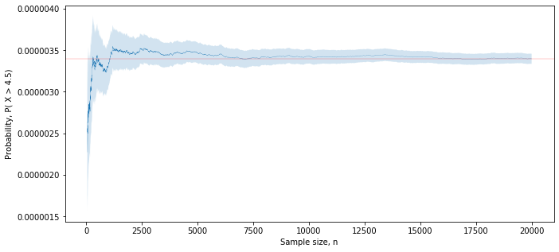

#### Características de una función de importancia apropiada

Una buena función de importancia debe tener las siguientes características:

- $f(X) > 0$ cuando $g(X) \neq 0$
- Para reducir la varianza $f(X)$ debería ser muy próxima a $|g(X)|$. Debemos intentar que $f(x) \propto |g(x)|$. En la práctica esto no es posible ya que la constante de proporcionalidad sería el valor de la integral buscada!!
- Debe ser sencillo (poco costoso) obtener una muestra de $f(x)$
- Debe ser sencillo evaluar la p.d.f de f(x) para cualquier valor de la muestra.

#### Aplicación del muestreo por importancia para estimación del valor esperado de una transformación

En la sección 3.1 vimos como estimar el valor esperado de una transformación continua $h(X)$ de una v.a $X$ cuya p.d.f es $f(x)$ \begin{equation} \mu = E \left[ h(x) \right] = \int_{\Omega} h(x) \, f(x) \, dx \label{y1} \end{equation} Para estimar el valor esperado (\ref{y1}) extraíamos una muestra de la distribución de $X$ y construíamos el estimador evaluando $h(X)$ para cada uno de los valores de la muestra, $$ \widehat{\mu} = \frac{1}{n} \sum_{i=1}^{n} h \left( X_i \right) \label{eq:estimador1} $$

Sin embargo pudiese ocurrir que en determinadas ocasiones no sea posible, o sea muy poco eficiente, obtener una muestra de $X$. En estas condiciones podemos utilizar una función de importancia $q(x)$ para estimar (\ref{y1}):

\begin{equation} \mu = E \left[ h(x) \right] = \int_{\Omega} h(x) \, f(x) \, dx = \int_{\Omega} \frac{ h(x) f(x) }{q(x)} q(x) \, dx \label{y2} \end{equation}

y estimar la integral anterior a partir de una muestra de $q(x)$

**Ejemplo VIII**

> Estimar el valor esperado del segundo momento de la variable aleatoria cuya p.d.f es $$ f(x) = \frac{1}{2} e^{-|x|} $$

> *Solución:*

> Debemos estimar $$ I = \int_{-\infty}^{\infty} x^2 \frac{1}{2} e^{-|x|} \, dx = 2 $$ Para ello podemos utilizar una muestra de $f(x)$ como vimos en la sección 3.1. Sin embargo, si carecemos de un algoritmo para obtener la muestra (o no es eficiente) podemos utilizar como función de importancia una p.d.f $q(x)$. Para este ejemplo una posible $\sim \mathcal{N}(0, 4)$

> Teniendo en cuenta que $\frac{1}{\sqrt{8 \pi}} e^{-x² / 8}$ es la p.d.f de una distribución $\mathcal{N}(0, 4)$, estimaremos el valor esperado $$ \hat{I} = E \left[ X^2 \frac{ \frac{1}{2} e^{-|X|} }{ \frac{1}{\sqrt{8 \pi}} e^{-X^2 / 8} } \right] $$ utilizando una muestra $\{ X_1, X_2, \ldots, X_n \}$ de $\mathcal{N}(0, 4)$.

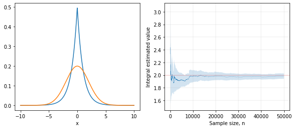

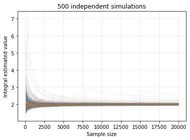

## Rendimiento algoritmos

Hemos visto dos algoritmos de Monte Carlo diferentes para integrar una función $g(x)$: uno basado en medias y el de aceptación/rechazo. En ambos, como consecuencia del Teorema central del límite, el error disminuye como $O\left( \frac{1}{\sqrt{n}} \right)$. Sin embargo las varianzas de ambos algoritmos son diferentes ya que trabajan con variables aleatorias diferentes. El de aceptación / rechazo con una distribución de Bernoulli y el de medias con la distribución de $Y$ obtenida a partir de la transformación $Y= h(x)$ y la variable aleatoria $X$. Nos preguntamos, para un valor del error $\delta$ ¿Cual de los dos necesitará una muestra menor? Aquel que tenga una menor varianza $\sigma^2$?

$$ n \sim \left( \frac{ z_{\alpha / 2 } \, \sigma}{\text{error}} \right)^2 $$

Es fácil demostrar que en general, el algoritmo basado en medias tendrá una menor varianza que el de aceptación / rechazo (Neal 1993).

## Comparación Monte Carlo frente a integración numérica

Integración numérica (1 dimensión):

- Punto medio: $O(1/N)$
- Regla trapezoidal: $O(1/N^2)$
- Simpson: $O(1/N^4)$

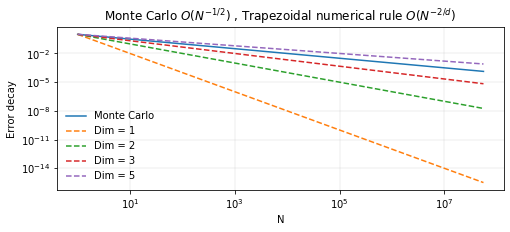

## Para finalizar....

### *on-line*

En los programas utilizados en los ejercicios los datos obtenidos a partir de la simulación se han almacenado en una array y, una vez finalizada la simulación, se calcula el valor del estimador y su varianza.

Sin embargo, a menudo es útil poder calcular media y la varianza en una sola pasada, esto es, inspeccionando cada valor obtenido en la simulación $x_ {i}$ una única vez. Por ejemplo, cuando no se dispone de suficiente espacio de almacenamiento para mantener todos los valores o cuando el coste de acceso a la memoria domina a los costes de computación. Los algoritmo *en línea*, utilizan una relación de recurrencia entre cantidades con las que se calculan las estadísticas requeridas:

Las fórmulas siguientes se pueden utilizar para actualizar la media $\widehat x_{n-1}$ y la varianza del estimador cuando se recibe un elemento adicional $x_n$:

\begin{align*} \widehat x_n &= \widehat x_{n-1} + \frac{x_n - \widehat x_{n-1} }{n} \\ s^2_n &= s^2_{n-1} + \frac{ \left( x_n - \widehat x_{n-1} \right)^2 }{n} - \frac{s^2_{n-1} }{n-1} \ \ n>1 \\ \sigma^2_n &= \sigma^2_{n-1} + \frac{ \left( x_n - \widehat x_{n-1} \right) \left( x_n - \widehat x_{n} \right) - \sigma^2_{n-1} }{n} \end{align*}

donde $x_n$ denota un elemento adicional, $\widehat x_n$ la media muestral tras recibir el elemnto adicional, $s²$ la media muestral y $\sigma²$ la varianza del estimador.

Este algoritmo puede ser *refinado* para evitar inestabilidades numéricas como el término $ \left( x_n - \widehat x_{n-1} \right)^2 $ (Wleford).

**Referencias:**

- Eric C. Anderson, Monte Carlo and Importance sampling, (1999) http://ib.berkeley.edu/labs/slatkin/eriq/classes/guest_lect/mc_lecture_notes.pdf.
- D. Neal, Determining sample sizes for Monte Carlo integrations, The collage mathematical journal, vol 24, p. 254 (1993) https://www.jstor.org/stable/2686489